# Adult data

Shrinath

June 22, 2018

In this project we will be working with the UCI adult dataset. I will be attempting to predict if people in the data set belong in a certain class by salary, either making <=50k or >50k per year.

Typically most of your time is spent cleaning data, not running the few lines of code that build your model, this project will try to reflect that by showing different issues that may arise when cleaning data.

Get the Data Import the data file and set it to a data frame called mydf.

```r
library(data.table)

mydf <-fread("https://archive.ics.uci.edu/ml/machine-learning-databases/adult/adult.data")
```

Check the head of adult

```r
head(mydf)
```

```
##    V1               V2     V3        V4 V5                 V6
## 1: 39        State-gov  77516 Bachelors 13      Never-married
## 2: 50 Self-emp-not-inc  83311 Bachelors 13 Married-civ-spouse
## 3: 38          Private 215646   HS-grad  9           Divorced
## 4: 53          Private 234721      11th  7 Married-civ-spouse
## 5: 28          Private 338409 Bachelors 13 Married-civ-spouse
## 6: 37          Private 284582   Masters 14 Married-civ-spouse
##                   V7            V8    V9    V10  V11 V12 V13           V14
## 1:      Adm-clerical Not-in-family White   Male 2174   0  40 United-States
## 2:   Exec-managerial       Husband White   Male    0   0  13 United-States
## 3: Handlers-cleaners Not-in-family White   Male    0   0  40 United-States
## 4: Handlers-cleaners       Husband Black   Male    0   0  40 United-States
## 5:    Prof-specialty          Wife Black Female    0   0  40          Cuba
## 6:   Exec-managerial          Wife White Female    0   0  40 United-States
##      V15
## 1: <=50K
## 2: <=50K
## 3: <=50K
## 4: <=50K
## 5: <=50K
## 6: <=50K
```

Since we don’t have the column names, therefore will name the coulmns

```r
colnames(mydf) <- c('age','workclass','fnlwgt','education','education-num','marital',
                    'occupation','relationship','race','sex','capital-gain',
                    'capital-loss','hours_per_week','country','income')

head(mydf)
```

```
##    age        workclass fnlwgt education education-num            marital
## 1:  39        State-gov  77516 Bachelors            13      Never-married
## 2:  50 Self-emp-not-inc  83311 Bachelors            13 Married-civ-spouse
## 3:  38          Private 215646   HS-grad             9           Divorced
## 4:  53          Private 234721      11th             7 Married-civ-spouse
## 5:  28          Private 338409 Bachelors            13 Married-civ-spouse
## 6:  37          Private 284582   Masters            14 Married-civ-spouse
##           occupation  relationship  race    sex capital-gain capital-loss
## 1:      Adm-clerical Not-in-family White   Male         2174            0
## 2:   Exec-managerial       Husband White   Male            0            0
## 3: Handlers-cleaners Not-in-family White   Male            0            0
## 4: Handlers-cleaners       Husband Black   Male            0            0
## 5:    Prof-specialty          Wife Black Female            0            0
## 6:   Exec-managerial          Wife White Female            0            0
##    hours_per_week       country income
## 1:             40 United-States  <=50K
## 2:             13 United-States  <=50K
## 3:             40 United-States  <=50K
## 4:             40 United-States  <=50K
## 5:             40          Cuba  <=50K
## 6:             40 United-States  <=50K
```

Lets check the data type of each variable

```r
str(mydf)
```

```
## Classes 'data.table' and 'data.frame':   32561 obs. of  15 variables:
##  $ age           : int  39 50 38 53 28 37 49 52 31 42 ...
##  $ workclass     : chr  "State-gov" "Self-emp-not-inc" "Private" "Private" ...
##  $ fnlwgt        : int  77516 83311 215646 234721 338409 284582 160187 209642 45781 159449 ...
##  $ education     : chr  "Bachelors" "Bachelors" "HS-grad" "11th" ...
##  $ education-num : int  13 13 9 7 13 14 5 9 14 13 ...
##  $ marital       : chr  "Never-married" "Married-civ-spouse" "Divorced" "Married-civ-spouse" ...
##  $ occupation    : chr  "Adm-clerical" "Exec-managerial" "Handlers-cleaners" "Handlers-cleaners" ...
##  $ relationship  : chr  "Not-in-family" "Husband" "Not-in-family" "Husband" ...
##  $ race          : chr  "White" "White" "White" "Black" ...
##  $ sex           : chr  "Male" "Male" "Male" "Male" ...
##  $ capital-gain  : int  2174 0 0 0 0 0 0 0 14084 5178 ...
##  $ capital-loss  : int  0 0 0 0 0 0 0 0 0 0 ...
##  $ hours_per_week: int  40 13 40 40 40 40 16 45 50 40 ...
##  $ country       : chr  "United-States" "United-States" "United-States" "United-States" ...
##  $ income        : chr  "<=50K" "<=50K" "<=50K" "<=50K" ...
##  - attr(*, ".internal.selfref")=<externalptr>
```

```r
summary(mydf)
```

```
##       age         workclass             fnlwgt         education
##  Min.   :17.00   Length:32561       Min.   :  12285   Length:32561
##  1st Qu.:28.00   Class :character   1st Qu.: 117827   Class :character
##  Median :37.00   Mode  :character   Median : 178356   Mode  :character
##  Mean   :38.58                      Mean   : 189778
##  3rd Qu.:48.00                      3rd Qu.: 237051
##  Max.   :90.00                      Max.   :1484705
##  education-num     marital           occupation        relationship
##  Min.   : 1.00   Length:32561       Length:32561       Length:32561
##  1st Qu.: 9.00   Class :character   Class :character   Class :character
##  Median :10.00   Mode  :character   Mode  :character   Mode  :character
##  Mean   :10.08
##  3rd Qu.:12.00
##  Max.   :16.00
##      race               sex             capital-gain    capital-loss
##  Length:32561       Length:32561       Min.   :    0   Min.   :   0.0
##  Class :character   Class :character   1st Qu.:    0   1st Qu.:   0.0
##  Mode  :character   Mode  :character   Median :    0   Median :   0.0
##                                        Mean   : 1078   Mean   :  87.3
##                                        3rd Qu.:    0   3rd Qu.:   0.0
##                                        Max.   :99999   Max.   :4356.0
##  hours_per_week    country             income
##  Min.   : 1.00   Length:32561       Length:32561
##  1st Qu.:40.00   Class :character   Class :character
##  Median :40.00   Mode  :character   Mode  :character
##  Mean   :40.44
##  3rd Qu.:45.00
##  Max.   :99.00
```

Data Cleaning Notice that we have a lot of columns that are cateogrical factors, however a lot of these columns have too many factors than may be necessary. In this data cleaning section we’ll try to clean these columns up by reducing the number of factors.

```r
table(mydf$workclass)
```

```
##
##                ?      Federal-gov        Local-gov     Never-worked
##             1836              960             2093                7
##          Private     Self-emp-inc Self-emp-not-inc        State-gov
##            22696             1116             2541             1298
##      Without-pay
##               14
```

Never-worked and without pay can be put into one category i.e ‘unemployed’

```r
unemp <- function(job){
    job <- as.character(job)
    if (job=='Never-worked' | job=='Without-pay'){
        return('Unemployed')
    }else{
        return(job)
    }
}
mydf$workclass <- sapply(mydf$workclass,unemp)

table(mydf$workclass)
```

```
##
##                ?      Federal-gov        Local-gov          Private
##             1836              960             2093            22696
##     Self-emp-inc Self-emp-not-inc        State-gov       Unemployed
##             1116             2541             1298               21
```

```r
group_emp <- function(job){
    if (job=='Local-gov' | job=='State-gov'){
        return('SL-gov')
    }else if (job=='Self-emp-inc' | job=='Self-emp-not-inc'){
        return('self-emp')
    }else{
        return(job)
    }
}

mydf$workclass <- sapply(mydf$workclass,group_emp)

table(mydf$workclass)
```

```
##
##           ? Federal-gov     Private    self-emp      SL-gov  Unemployed
##        1836         960       22696        3657        3391          21
```

```r
table(mydf$marital)
```

```
##
##              Divorced     Married-AF-spouse    Married-civ-spouse
##                  4443                    23                 14976
## Married-spouse-absent         Never-married             Separated
##                   418                 10683                  1025
##               Widowed
##                   993
```

```r
group_marital <- function(mar){
    mar <- as.character(mar)

    # Not-Married
    if (mar=='Separated' | mar=='Divorced' | mar=='Widowed'){
        return('Not-Married')

    # Never-Married
    }else if(mar=='Never-married'){
        return(mar)

     #Married
    }else{
        return('Married')
    }
}

mydf$marital <- sapply(mydf$marital,group_marital)
table(mydf$marital)
```

```
##
##       Married Never-married   Not-Married
##         15417         10683          6461
```

```r
table(mydf$country)
```

```
##
##                          ?                   Cambodia
##                        583                         19
##                     Canada                      China
##                        121                         75
##                   Columbia                       Cuba
##                         59                         95
##         Dominican-Republic                    Ecuador
##                         70                         28
##                El-Salvador                    England
##                        106                         90
##                     France                    Germany
##                         29                        137
##                     Greece                  Guatemala
##                         29                         64
##                      Haiti         Holand-Netherlands
##                         44                          1
##                   Honduras                       Hong
##                         13                         20
##                    Hungary                      India
##                         13                        100
##                       Iran                    Ireland
##                         43                         24
##                      Italy                    Jamaica
##                         73                         81
##                      Japan                       Laos
##                         62                         18
##                     Mexico                  Nicaragua
##                        643                         34
## Outlying-US(Guam-USVI-etc)                       Peru
##                         14                         31
##                Philippines                     Poland
##                        198                         60
##                   Portugal                Puerto-Rico
##                         37                        114
##                   Scotland                      South
##                         12                         80
##                     Taiwan                   Thailand
##                         51                         18
##            Trinadad&Tobago              United-States
##                         19                      29170
##                    Vietnam                 Yugoslavia
##                         67                         16
```

If we see carefully this country column doesn’t having all the countries. SO i will group it by continent.

```r
Asia <- c('China','Hong','India','Iran','Cambodia','Japan', 'Laos' ,
          'Philippines' ,'Vietnam' ,'Taiwan', 'Thailand')

North.America <- c('Canada','United-States','Puerto-Rico' )

Europe <- c('England' ,'France', 'Germany' ,'Greece','Holand-Netherlands','Hungary',
            'Ireland','Italy','Poland','Portugal','Scotland','Yugoslavia')

Latin.and.South.America <- c('Columbia','Cuba','Dominican-Republic','Ecuador',
                             'El-Salvador','Guatemala','Haiti','Honduras',
                             'Mexico','Nicaragua','Outlying-US(Guam-USVI-etc)','Peru',
                            'Jamaica','Trinadad&Tobago')
Other <- c('South')
```

```r
group_country <- function(ctry){
    if (ctry %in% Asia){
        return('Asia')
    }else if (ctry %in% North.America){
        return('North.America')
    }else if (ctry %in% Europe){
        return('Europe')
    }else if (ctry %in% Latin.and.South.America){
        return('Latin.and.South.America')
    }else{
        return('Other')
    }
}

mydf$country <- sapply(mydf$country,group_country)
table(mydf$country)
```

```
##
##                    Asia                  Europe Latin.and.South.America
##                     671                     521                    1301
##           North.America                   Other
##                   29405                     663
```

```r
mydf$workclass <- sapply(mydf$workclass,factor)
mydf$country <- sapply(mydf$country,factor)
mydf$marital <- sapply(mydf$marital,factor)
mydf$education <- sapply(mydf$education,factor)
mydf$relationship <- sapply(mydf$relationship,factor)
mydf$race <- sapply(mydf$race,factor)
mydf$sex <- sapply(mydf$sex,factor)
mydf$income <- sapply(mydf$income,factor)
mydf$occupation <- sapply(mydf$occupation,factor)


str(mydf)
```

```
## Classes 'data.table' and 'data.frame':   32561 obs. of  15 variables:
##  $ age           : int  39 50 38 53 28 37 49 52 31 42 ...
##  $ workclass     : Factor w/ 6 levels "SL-gov","self-emp",..: 1 2 3 3 3 3 3 2 3 3 ...
##  $ fnlwgt        : int  77516 83311 215646 234721 338409 284582 160187 209642 45781 159449 ...
##  $ education     : Factor w/ 16 levels "Bachelors","HS-grad",..: 1 1 2 3 1 4 5 2 4 1 ...
##  $ education-num : int  13 13 9 7 13 14 5 9 14 13 ...
##  $ marital       : Factor w/ 3 levels "Never-married",..: 1 2 3 2 2 2 2 2 1 2 ...
##  $ occupation    : Factor w/ 15 levels "Adm-clerical",..: 1 2 3 3 4 2 5 2 4 2 ...
##  $ relationship  : Factor w/ 6 levels "Not-in-family",..: 1 2 1 2 3 3 1 2 1 2 ...
##  $ race          : Factor w/ 5 levels "White","Black",..: 1 1 1 2 2 1 2 1 1 1 ...
##  $ sex           : Factor w/ 2 levels "Male","Female": 1 1 1 1 2 2 2 1 2 1 ...
##  $ capital-gain  : int  2174 0 0 0 0 0 0 0 14084 5178 ...
##  $ capital-loss  : int  0 0 0 0 0 0 0 0 0 0 ...
##  $ hours_per_week: int  40 13 40 40 40 40 16 45 50 40 ...
##  $ country       : Factor w/ 5 levels "North.America",..: 1 1 1 1 2 1 2 1 1 1 ...
##  $ income        : Factor w/ 2 levels "<=50K",">50K": 1 1 1 1 1 1 1 2 2 2 ...
##  - attr(*, ".internal.selfref")=<externalptr>
```

Missing Data Converting any cell with a ‘?’ or a ‘?’ value to a NA value

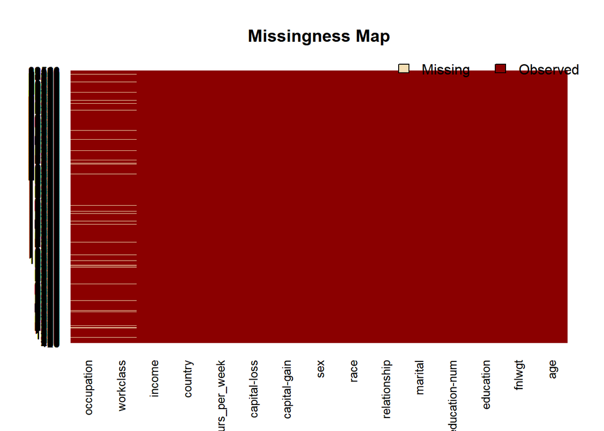

```r
library(Amelia)
mydf[mydf == '?'] <- NA
missmap(mydf)
```

```r
# May take awhile
mydf <- na.omit(mydf)
```

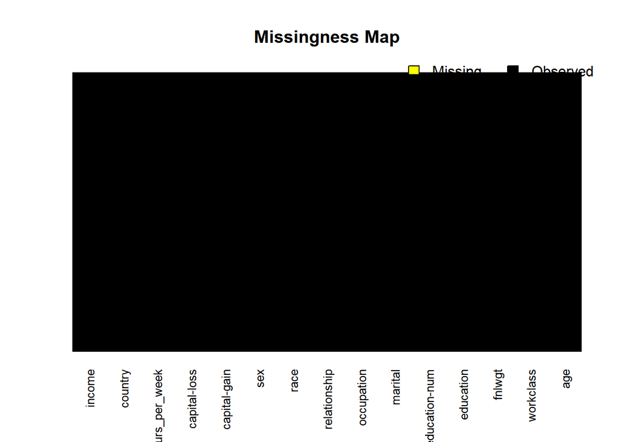

```r
missmap(mydf,y.at=c(1),y.labels = c(''),col=c('yellow','black'))
```

Exploratory Data analysis

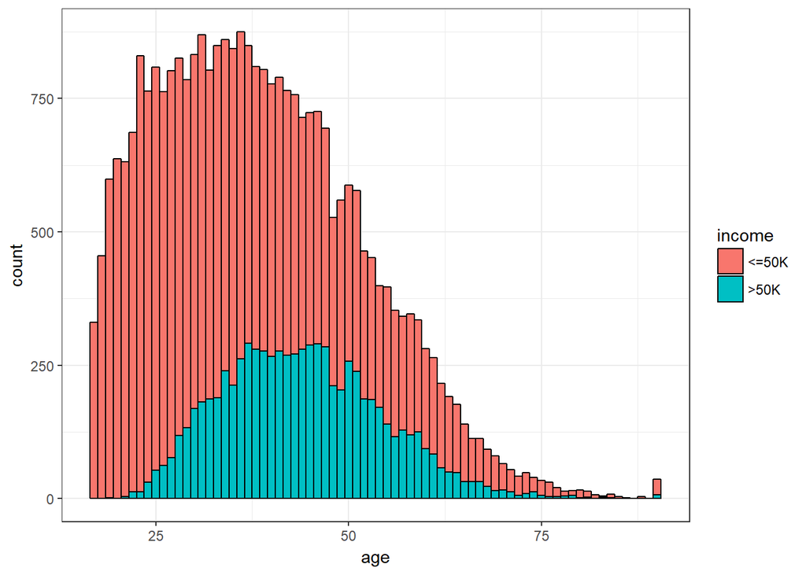

```r
library(ggplot2)
library(dplyr)
ggplot(mydf,aes(age)) + geom_histogram(aes(fill=income),color='black',binwidth=1) + theme_bw()
```

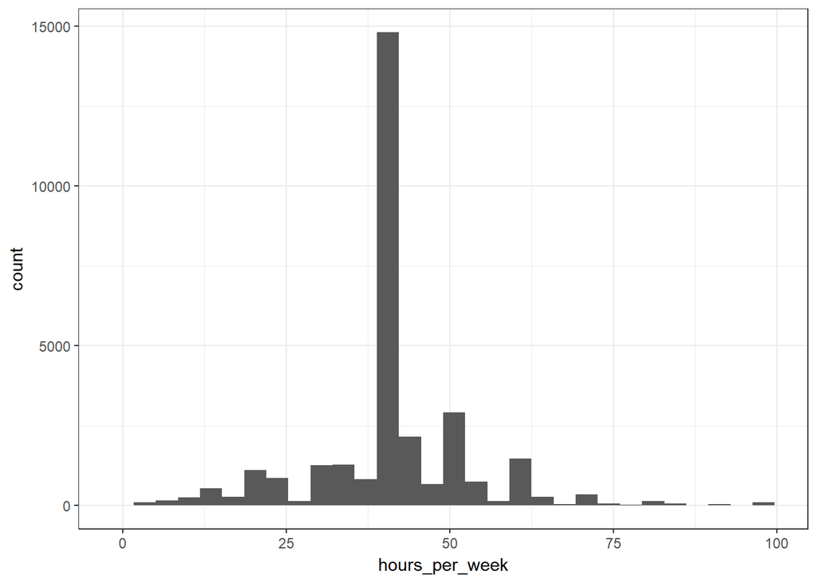

```r
ggplot(mydf,aes(hours_per_week)) + geom_histogram() + theme_bw()
```

Building a model

```r
# Import Library
library(caTools)

# Set a random see so your "random" results are the same as this notebook
set.seed(101)

# Split up the sample, basically randomly assigns a booleans to a new column "sample"
sample <- sample.split(mydf$income, SplitRatio = 0.70) # SplitRatio = percent of sample==TRUE

# Training Data
train = subset(mydf, sample == TRUE)

# Testing Data
test = subset(mydf, sample == FALSE)
```

```r
model = glm(income ~ ., family = binomial(logit), data = train)
summary(model)
```

```
##
## Call:
## glm(formula = income ~ ., family = binomial(logit), data = train)
##
## Deviance Residuals:
##     Min       1Q   Median       3Q      Max
## -5.1163  -0.5172  -0.1965   0.0000   3.6235
##
## Coefficients: (1 not defined because of singularities)
##                                  Estimate Std. Error z value Pr(>|z|)
## (Intercept)                    -4.682e+00  1.829e-01 -25.599  < 2e-16 ***
## age                             2.534e-02  2.007e-03  12.627  < 2e-16 ***
## workclassself-emp               7.501e-03  8.999e-02   0.083 0.933571
## workclassPrivate                2.371e-01  7.321e-02   3.239 0.001198 **
## workclassFederal-gov            6.835e-01  1.266e-01   5.399 6.71e-08 ***
## workclassUnemployed            -1.346e+01  3.688e+02  -0.036 0.970888
## fnlwgt                          5.424e-07  2.085e-07   2.601 0.009291 **
## educationHS-grad               -1.167e+00  6.599e-02 -17.683  < 2e-16 ***
## education11th                  -1.793e+00  1.876e-01  -9.561  < 2e-16 ***
## educationMasters                3.441e-01  9.217e-02   3.734 0.000189 ***
## education9th                   -2.015e+00  2.673e-01  -7.539 4.73e-14 ***
## educationSome-college          -7.997e-01  6.727e-02 -11.888  < 2e-16 ***
## educationAssoc-acdm            -7.527e-01  1.188e-01  -6.337 2.35e-10 ***
## educationAssoc-voc             -5.504e-01  1.056e-01  -5.211 1.88e-07 ***
## education7th-8th               -2.502e+00  2.292e-01 -10.914  < 2e-16 ***
## educationDoctorate              8.707e-01  1.862e-01   4.677 2.91e-06 ***
## educationProf-school            7.946e-01  1.620e-01   4.904 9.41e-07 ***
## education5th-6th               -2.083e+00  3.581e-01  -5.817 6.01e-09 ***
## education10th                  -2.003e+00  1.938e-01 -10.337  < 2e-16 ***
## education1st-4th               -2.462e+00  5.813e-01  -4.235 2.29e-05 ***
## educationPreschool             -2.079e+01  1.645e+02  -0.126 0.899407
## education12th                  -1.610e+00  2.915e-01  -5.524 3.32e-08 ***
## `education-num`                        NA         NA      NA       NA
## maritalMarried                  1.280e+00  1.943e-01   6.588 4.45e-11 ***
## maritalNot-Married              5.435e-01  9.953e-02   5.460 4.75e-08 ***
## occupationExec-managerial       7.689e-01  9.095e-02   8.453  < 2e-16 ***
## occupationHandlers-cleaners    -7.944e-01  1.726e-01  -4.603 4.17e-06 ***
## occupationProf-specialty        4.957e-01  9.626e-02   5.149 2.62e-07 ***
## occupationOther-service        -8.248e-01  1.386e-01  -5.952 2.65e-09 ***
## occupationSales                 2.896e-01  9.749e-02   2.971 0.002972 **
```

[output cut: 20 more lines]

```
## hours_per_week                  2.906e-02  1.987e-03  14.623  < 2e-16 ***
## countryLatin.and.South.America -5.925e-01  1.595e-01  -3.714 0.000204 ***
## countryAsia                    -6.475e-02  2.044e-01  -0.317 0.751446
## countryOther                   -4.300e-01  1.651e-01  -2.604 0.009206 **
## countryEurope                   4.404e-02  1.552e-01   0.284 0.776660
## ---
## Signif. codes:  0 '***' 0.001 '**' 0.01 '*' 0.05 '.' 0.1 ' ' 1
##
## (Dispersion parameter for binomial family taken to be 1)
##
##     Null deviance: 24138  on 21502  degrees of freedom
## Residual deviance: 14004  on 21449  degrees of freedom
## AIC: 14112
##
## Number of Fisher Scoring iterations: 14
```

We have still a lot of features! Some important, some not so much. R comes with an awesome function called step(). The step() function iteratively tries to remove predictor variables from the model in an attempt to delete variables that do not significantly add to the fit. How does it do this? It uses AIC.

```r
new.step.model <- step(model)
```

```
## Start:  AIC=14112.05
## income ~ age + workclass + fnlwgt + education + `education-num` +
##     marital + occupation + relationship + race + sex + `capital-gain` +
##     `capital-loss` + hours_per_week + country
```

```
##
## Step:  AIC=14112.05
## income ~ age + workclass + fnlwgt + education + marital + occupation +
##     relationship + race + sex + `capital-gain` + `capital-loss` +
##     hours_per_week + country
```

```
##                  Df Deviance   AIC
## <none>                 14004 14112
## - fnlwgt          1    14011 14117
## - race            4    14019 14119
## - country         4    14026 14126
## - workclass       4    14050 14150
## - marital         2    14060 14164
## - sex             1    14097 14203
## - age             1    14165 14271
## - `capital-loss`  1    14217 14323
## - hours_per_week  1    14222 14328
## - relationship    5    14288 14386
## - occupation     13    14444 14526
## - education      15    14718 14796
## - `capital-gain`  1    15248 15354
```

```r
summary(new.step.model)
```

```
##
## Call:
## glm(formula = income ~ age + workclass + fnlwgt + education +
##     marital + occupation + relationship + race + sex + `capital-gain` +
##     `capital-loss` + hours_per_week + country, family = binomial(logit),
##     data = train)
##
## Deviance Residuals:
##     Min       1Q   Median       3Q      Max
## -5.1163  -0.5172  -0.1965   0.0000   3.6235
##
## Coefficients:
##                                  Estimate Std. Error z value Pr(>|z|)
## (Intercept)                    -4.682e+00  1.829e-01 -25.599  < 2e-16 ***
## age                             2.534e-02  2.007e-03  12.627  < 2e-16 ***
## workclassself-emp               7.501e-03  8.999e-02   0.083 0.933571
## workclassPrivate                2.371e-01  7.321e-02   3.239 0.001198 **
## workclassFederal-gov            6.835e-01  1.266e-01   5.399 6.71e-08 ***
## workclassUnemployed            -1.346e+01  3.688e+02  -0.036 0.970888
## fnlwgt                          5.424e-07  2.085e-07   2.601 0.009291 **
## educationHS-grad               -1.167e+00  6.599e-02 -17.683  < 2e-16 ***
## education11th                  -1.793e+00  1.876e-01  -9.561  < 2e-16 ***
## educationMasters                3.441e-01  9.217e-02   3.734 0.000189 ***
## education9th                   -2.015e+00  2.673e-01  -7.539 4.73e-14 ***
## educationSome-college          -7.997e-01  6.727e-02 -11.888  < 2e-16 ***
## educationAssoc-acdm            -7.527e-01  1.188e-01  -6.337 2.35e-10 ***
## educationAssoc-voc             -5.504e-01  1.056e-01  -5.211 1.88e-07 ***
## education7th-8th               -2.502e+00  2.292e-01 -10.914  < 2e-16 ***
## educationDoctorate              8.707e-01  1.862e-01   4.677 2.91e-06 ***
## educationProf-school            7.946e-01  1.620e-01   4.904 9.41e-07 ***
## education5th-6th               -2.083e+00  3.581e-01  -5.817 6.01e-09 ***
## education10th                  -2.003e+00  1.938e-01 -10.337  < 2e-16 ***
## education1st-4th               -2.462e+00  5.813e-01  -4.235 2.29e-05 ***
## educationPreschool             -2.079e+01  1.645e+02  -0.126 0.899407
## education12th                  -1.610e+00  2.915e-01  -5.524 3.32e-08 ***
## maritalMarried                  1.280e+00  1.943e-01   6.588 4.45e-11 ***
## maritalNot-Married              5.435e-01  9.953e-02   5.460 4.75e-08 ***
## occupationExec-managerial       7.689e-01  9.095e-02   8.453  < 2e-16 ***
## occupationHandlers-cleaners    -7.944e-01  1.726e-01  -4.603 4.17e-06 ***
## occupationProf-specialty        4.957e-01  9.626e-02   5.149 2.62e-07 ***
```

[output cut: 22 more lines]

```
## hours_per_week                  2.906e-02  1.987e-03  14.623  < 2e-16 ***
## countryLatin.and.South.America -5.925e-01  1.595e-01  -3.714 0.000204 ***
## countryAsia                    -6.475e-02  2.044e-01  -0.317 0.751446
## countryOther                   -4.300e-01  1.651e-01  -2.604 0.009206 **
## countryEurope                   4.404e-02  1.552e-01   0.284 0.776660
## ---
## Signif. codes:  0 '***' 0.001 '**' 0.01 '*' 0.05 '.' 0.1 ' ' 1
##
## (Dispersion parameter for binomial family taken to be 1)
##
##     Null deviance: 24138  on 21502  degrees of freedom
## Residual deviance: 14004  on 21449  degrees of freedom
## AIC: 14112
##
## Number of Fisher Scoring iterations: 14
```

Creating a confusion matrix using the predict function with type=‘response’ as an argument inside of that function.

```r
test$predicted.income = predict(model, newdata=test, type="response")
table(test$income, test$predicted.income > 0.5)
```

```
##
##         FALSE TRUE
##   <=50K  6372  548
##   >50K    872 1423
```

Accuracy

```r
(6372+1423)/(6372+1423+548+872)
```

```
## [1] 0.8459034
```